# P9_vantyghem_notebook

### 5.2 Recommandations

Le **cluster 5** paraît être un cluster à cibler : il combine plusieurs caractéristiques économiques et sociales intéressantes concernant:

- la consommation de volaille par habitant
- la sécurité alimentaire / PIB par habitant
- la taille du marché
- la quantité d'import et la dynamique de hausse des importations sur le marché international

Parmi les pays du **cluster 5**, les pays tels que

- 'China, Taiwan Province of',
- 'Kazakhstan',
- 'Republic of Korea',
- 'Spain',
- 'Russian Federation'
- 'Turkey',
- 'Republic of Korea',
- 'Dominican Republic',
- 'Slovakia',
- 'Poland',
- 'Kuwait',
- 'Hungary'

font partie des **20 importateurs mondiaux les plus importants, et/ou des 20 pays ayant connu la plus forte croissance en parts d'import sur le marché mondial**.

Ce n'est toutefois pas le seul cluster d'intérêt et certains individus appartenant à d'autres clusters pourraint également être étudiés (Chine, Yemen, Vietnam par exemple).

D'autres problématiques peuvent entrer en considération, telles que les problématiques de distance/transport, qui présentent un coût économique comme environnemental. Si cette question est au coeur des problématiques de La poule qui chante, **les pays européens (appartenant au cluster 5 et 6) devraient être ciblés en majorité, tout comme les pays d'Afrique du Nord et du Proche Orient** (ex: Libye, Yemen, Turquie, qui appartiennent au cluster 3 ou 5 en fonction de la méthode) . Il existe d'ailleurs un phénomène d'intensification du marché intraeuropéen sur la filière poulet (source : https://www.franceagrimer.fr/fam/content/download/66965/document/20210625-COMPETITIVITE_CAHIER_VOLAILLES.pdf?version=6))

L'étude a permis également de mettre en avant un cluster de pays qui semble vouloir réduire sa dépendance aux importations : **le cluster 7 (Hong Kong, Arabie Saoudite, Iraq)**, ce qui se traduit par un forte baisse des parts d'import sur le marché international. C'est un cluster que l'on peut exclure de l'étude de marché, tout comme le **cluster 1 (Brésil, Etats Unis)**, qui sont des pays structurellement exportateurs.

L'étude de marché pourra cibler plus précisément certaines variables d'intérêt :

- comme l'évolution des imports (cf carte ci dessous),
- l'évolution de la consommation de volaille par habitant, et la hausse du niveau de vie (non étudiées ici) pour cibler des pays sur lesquels le marché "des volailles de qualité" est en croissance
- l'état des relations diplomatiques et commerciales avec la France.

```
Evolution des part d'import sur le marché mondial entre 2017 et 2019 (Chine et Vietnam non représentés)
```

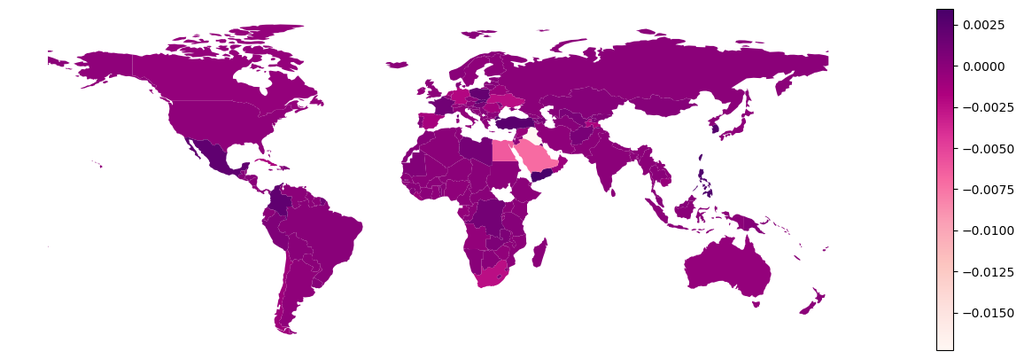

```python
print("Evolution des part d'import sur le marché mondial entre 2017 et 2019 (Chine et Vietnam non représentés)")
world[(world["name"] != "China") & (world["name"] != "Vietnam")].plot(column='Import share evolution 17-2019', cmap='RdPu', figsize=(20, 5), legend = True).axis('off')
plt.show()
```